# 上級マクロ経済学II

第8回 技術偏向的経済成長

Author

荻巣嘉高

# 1 スキル別賃金格差の拡大

## セクター別賃金

- 高技能労働者（high-skilled labor） vs 低技能労働者（low-skilled labor）
  - 高技能セクターと低技能セクターとか呼んだりもする．
  - よくある定式化だと，大卒と高卒
- 高卒者の賃金：$w_L$
- 大卒者の賃金：$w_H$

とすると，平均的に
$$w_H > w_L$$
（第6回参照）

## 賃金の決定

高技能労働を$H$，低技能労働を$L$とすると，競争均衡では
$$\frac{\partial Y}{\partial H} = w_H$$
$$\frac{\partial Y}{\partial L} = w_L$$

左辺は労働需要関数になっている．

## コブ・ダグラスでの労働需要

$$Y= K^{1-\alpha-\beta} H^{\alpha} L^{\beta}$$
だとすると，労働需要関数と賃金の関係性は，

$$\alpha \frac{K^{1-\alpha-\beta} L^{\beta}}{H^{1-\alpha}} = w_H$$
$$\beta \frac{K^{1-\alpha-\beta} H^{\alpha}}{L^{1-\beta}} = w_L$$

- $H$の上昇で$w_H$は減少
- $L$の上昇で$w_L$は減少

## 賃金の比

賃金プレミアム$\omega$を次のように定める．
$$\omega \equiv \frac{w_H}{w_L} = \frac{\alpha }{\beta} \left( \frac{L}{H} \right)$$
大卒者と高卒者の比率（大卒・高卒比率）が$H/L$

- $H/L$の上昇で賃金格差は縮小．

## 観測的事実

Acemoglu (2002)の議論

- 大卒・高卒比率は増加（大卒者の相対的な増加）
- 一方で賃金プレミアム（$\omega \equiv w_H/ w_L$）は増加

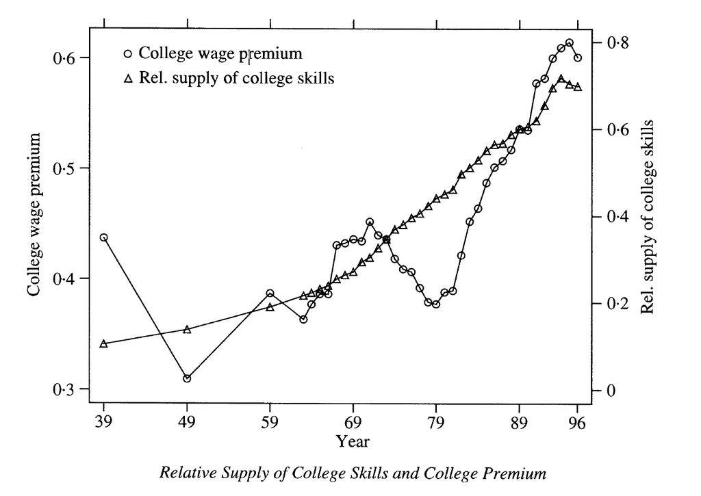

## 日本の賃金プレミアム

USほど急峻ではないが，トレンドは同じ．

- 新卒のみで観測
  - 初任給賃金
  - 初任者の大卒・高卒比率
- 大卒・高卒比率は増加（大卒者の相対的な増加）
- 一方で賃金プレミアム（$\omega \equiv w_H/ w_L$）は増加

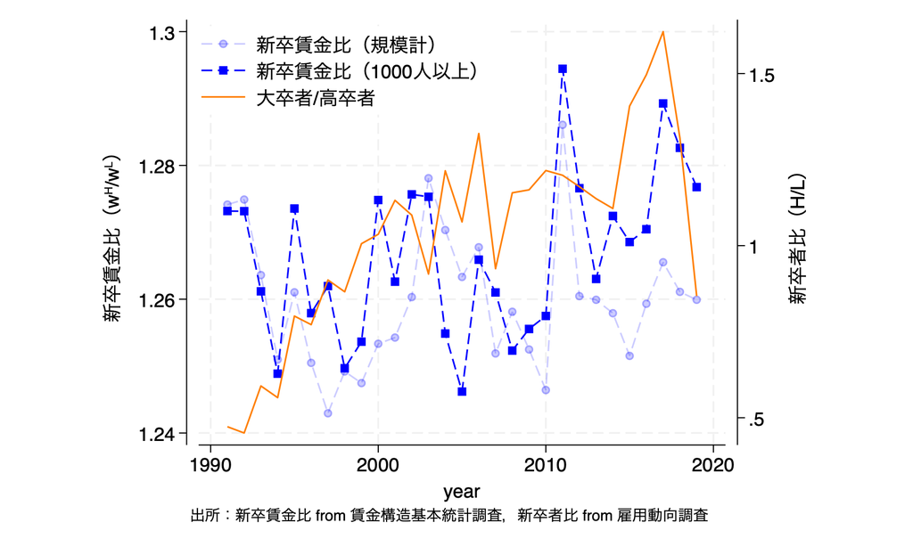

## 技術との親和性

- 高技能の労働者が増えている
  - 高技能労働者の供給が増えて，賃金に下落圧力
- その直接効果を上回る，賃金に上昇圧力をかける別の要因が存在．
- ひとつの説明は，高技能労働者と親和的なスキルの発展
  - **技能偏向的技術進歩** (Acemoglu, 2002)
  - コンピュータ，プログラミング，AI等，使い方を訓練すると生産性が向上する技術は各種存在．

# 2 ベーシックメカニズム

## 生産の仮定

- 生産には$H$と$L$を利用．
  - 簡単にするために，資本を省略．
- $H$と$L$にはそれぞれ技術水準$A_H$と$A_L$がかけられて，労働投入される．

## 生産関数

以下のような生産関数を仮定．
$$Y = \left[ \gamma_H (A_H H)^{\frac{\epsilon - 1}{\epsilon}} + \gamma_L (A_L L)^{\frac{\epsilon - 1}{\epsilon}} \right]^{\frac{\epsilon}{\epsilon - 1}}$$

- ただし，$\epsilon > 0$，$\gamma_H+\gamma_L = 1$．
- このような関数形をCES（Constant Elasticity of Substitution；代替の弾力性一定）関数と呼ぶ．
  - $\epsilon$は代替の弾力性と呼ばれる．
  - $\epsilon \to 1$の時の極限は，コブ・ダグラス型生産関数（$Y=(A_H H)^{\gamma_H} (A_L L)^{\gamma_L}$）になる．

## 賃金の決定

$$\frac{\partial Y}{\partial H} = \gamma_H A_H^{\frac{\epsilon - 1}{\epsilon}} \left( \frac{Y}{H} \right)^{\frac{1}{\epsilon}} = w_H$$

$$\frac{\partial Y}{\partial L} = \gamma_L A_L^{\frac{\epsilon - 1}{\epsilon}} \left( \frac{Y}{L} \right)^{\frac{1}{\epsilon}} = w_L$$

- 労働需要関数は各要素（$H$，$L$）に対して右下がり．

## 賃金の比率

賃金の比率は，以下の通りで与えられる．
$$\omega \equiv \frac{\gamma_H}{\gamma_L} \left( \frac{A_H}{A_L}\right)^{\frac{\epsilon -1}{\epsilon}} \left( \frac{L}{H} \right)^{\frac{1}{\epsilon}}$$

- $H/L$が上昇したとき：
  - $A_H/A_L$が不変なら$\omega$は減少．
  - $A_H/A_L$が大きく上昇するなら，$\omega$は増加しうる．
- コブ・ダグラスのケースは$\epsilon \to 1$なので，$A_H/A_L$は無関係になる．
  - $H$と$L$の代替関係の大きさ&技術進歩の反応がキー．

## 補足：代替の弾力性

代替の弾力性は1%の価格比の変化に対する要素比の変化．

- 今回のケースだと:
  - $\omega=w_H/w_L$が価格比．
  - $H/L$が要素比．
    $$\log \left( \frac{H}{L} \right) = - \epsilon \log \omega + \epsilon \log \frac{\gamma_H}{\gamma_L} + (\epsilon -1)\log \left( \frac{A_H}{A_L}\right)$$

$$代替の弾力性 = - \frac{\partial \log (H/L)}{\partial \log \omega} = \epsilon$$

# 3 Simplified Acemoglu (2002) model

## 設定

- Acemoglu (2002)をベースに，簡単化した静学モデルを紹介．
- 最終財$Y$生産のために，中間財2つを利用．
  - $Y_{H}$：高技能労働中間財
  - $Y_{L}$：低技能労働中間財
- 各中間財の生産において，生産性（技術水準）$A_{H}$，$A_{L}$が活用される．
  - $A_{H}$，$A_{L}$は生産要素が用いられれば，学習によって高まっていく．
    - 一種のlearning by doing．
- 全ての市場は完全競争．
- 人口成長なしで，$L$，$H$は一定．

## 最終財生産企業

次の生産関数のもとで生産．
$$Y = \left[ \gamma_H Y_{H}^{\frac{\epsilon - 1}{\epsilon}} + \gamma_L Y_{L}^{\frac{\epsilon-1}{\epsilon}} \right]^{\frac{\epsilon}{\epsilon - 1}}$$
最終財の価格を1に基準化すると，利潤$\pi^{Y}$は
$$\pi^{Y} = Y - p_H Y_{H} - p_L Y_{L}$$
$p_{H}$，$p_{L}$は中間財$Y_{H}$，$Y_{L}$の価格．

## 中間財生産企業

$$\begin{aligned}
Y_{H} &= A_{H} H \\
Y_{L} &= A_{L} L
\end{aligned}$$

- $A_{H}$，$A_{L}$は企業にとっては所与．

利潤はそれぞれ，
$$\begin{aligned}
\pi^{H} &= p_H Y_{H} - w_{H} H \\
\pi^{L} &= p_L Y_{L} - w_{L} L
\end{aligned}$$

## 技術水準

$$\begin{aligned}
A_{H} = B_H H^{\epsilon - 1} \\
A_{L} = B_L L^{\epsilon - 1}
\end{aligned}$$

- それぞれの生産技術は，利用されている技術に応じて成長する．
- 一種の外部性だが，その大きさは$\epsilon$の大きさによる．

## 最終財企業の利潤最大化

$$\frac{\partial \pi^{Y}}{\partial Y_{H}} = \gamma_H \left(\frac{Y}{Y_{H}}\right)^{\frac{1}{\epsilon}} - p_H = 0$$
$$\frac{\partial \pi^{Y}}{\partial Y_{L}} = \gamma_L \left(\frac{Y}{Y_{L}}\right)^{\frac{1}{\epsilon}} - p_L = 0$$

したがって，
$$\frac{p_H}{p_L} = \frac{\gamma_H}{\gamma_L} \left( \frac{Y_{L}}{Y_{H}} \right)^{\frac{1}{\epsilon}}$$

## 中間財企業の市場清算

市場競争下では$\pi^{H}=\pi^{L}=0$なので，
$$\begin{aligned}
p_H A_{H} &= w_{H} \\
p_L A_{L} &= w_{L}
\end{aligned}$$

- もとの問題は線形なので，微分できないことに注意．

賃金比は，
$$\frac{w_{H}}{w_{L}} = \frac{A_{H}}{A_{L}} \frac{p_H}{p_L}$$

## 賃金プレミアム

順に代入していくと，賃金プレミアムは次のようになる．
$$\omega = \frac{w_{H}}{w_{L}} = \frac{\gamma_H}{\gamma_L} \left( \frac{A_{H}}{A_{L}} \right)^{\frac{\epsilon - 1}{\epsilon}}\left( \frac{L}{ H} \right)^{\frac{1}{\epsilon}}$$

均斉成長経路においては$A_{H,t}$，$A_{L,t}$の蓄積が反映される．

$$\omega = \frac{w_{H}}{w_{L}} = B \frac{\gamma_H}{\gamma_L} \left( \frac{H}{L} \right)^{\epsilon - 2}$$

ただし，$B \equiv (B_H/B_L)^{\frac{\epsilon-1}{\epsilon}}$

## 代替の弾力性と賃金プレミアム

$$\omega = B \frac{\gamma_H}{\gamma_L} \left( \frac{H}{L} \right)^{\epsilon - 2}$$

$H$増加による反応は$\epsilon$によって変わる：

- $\epsilon < 2$なら，$\omega$低下．
- $\epsilon = 2$なら，$\omega$に変化はない．
- $\epsilon > 2$なら，$\omega$上昇．

## 代替の大きさと技術進歩

$H$の増加から$\omega$変化への経路は2つ．

$$\omega = \underbrace{\frac{A_{H}}{A_{L}}}_{(+) 生産性効果} \underbrace{\frac{p_H}{p_L} }_{(-)価格効果}$$

$A_H$の上昇が$w_H=A_H p_H$を直接押し上げる一方，中間財の「代替しやすさ」が$p_H$の下落を弱める．

綱引きの結果は以下の反応に依存：

- $H$の（相対的な）上昇が$A_H$をどれほど高めるか（関数形）
- $H$の（相対的な）上昇が$p_H$の下落をどれほど弱めるか（代替の弾力性）

## Reference

- Acemoglu, D. (2002) “Directed technical change,” *Review of Economic Studies*, 69.